# Collinearity

Econometrics - ECON 426

## Collinearity

## Collinearity

- When data are the result of an uncontrolled experiment, many of the economic variables may move together in systematic ways
- *Multicollinearity* is the term used to describe the correlation among the independent variables.
- A *multicollinearity problem* occurs when this correlation is high.

## Determining if multicollinearity is a problem

- Variance inflation factor
- Pairs Plot

## Variance inflation factor

```r
data("cars", package="PoEdata")
cars.lm <- lm(mpg ~ . , data=cars)
jtools::summ(cars.lm, vifs=T)
```

```
MODEL INFO:
Observations: 392
Dependent Variable: mpg
Type: OLS linear regression

MODEL FIT:
F(3,388) = 300.76, p = 0.00
R² = 0.70
Adj. R² = 0.70

Standard errors: OLS
--------------------------------------------------------
                     Est.   S.E.   t val.      p     VIF
----------------- ------- ------ -------- ------ -------
(Intercept)         44.37   1.48    29.97   0.00
cyl                 -0.27   0.41    -0.65   0.52   10.52
eng                 -0.01   0.01    -1.54   0.13   15.79
wgt                 -0.01   0.00    -8.00   0.00    7.79
--------------------------------------------------------
```

## Pairs Plot

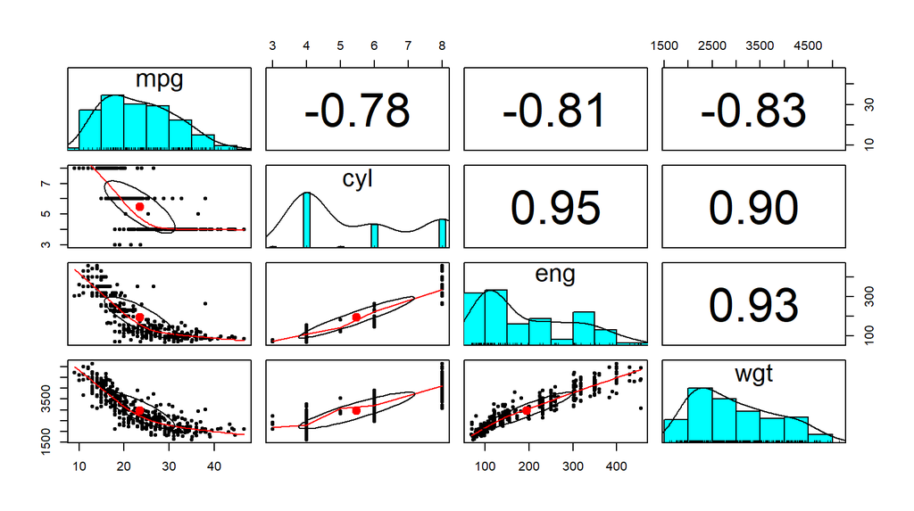

```r
psych::pairs.panels(cars)
```

## Collinearity and Joint Significance

## The Hot Dog Case

- Your company: Dubuque.
- Ball Park: a leading brand.
- Ball Park may reduce hot dog price. *Problem:* Impact on Dubuque’s market share.
- Some argue that the impact will be small because Oscar Mayer is Dubuque’s leading competitor.

## The Hot Dog Case Background

- Ball Park produces two Hot Dogs.
  - Regular and All-beef Hot Dogs.
- Current Prices:
  - Ball Park 1.79 and 1.89 (regular and beef)
  - Dubuque 1.49
  - Oscar Mayer 1.69
- Ball Park new pricing:
  - Regular 1.45, All-beef 1.55

## The Question

What will happen to Dubuque’s market share if Dubuque does not respond to Ball Park’s new campaign?

## Load and Examen the Data

```r
hotdog <- read.csv("data/Hotdog.csv")
head(hotdog)
```

```
     MKTDUB pdub poscar pbpreg pbpbeef
1 0.0454565  149    169    169     180
2 0.0930145  149    199    189     205
3 0.0596656  189    199    189     205
4 0.0345966  189    199    189     201
5 0.0276536  189    169    159     166
6 0.0294224  189    199    189     196
```

## Linear Model

```r
hotdog.lm01 = lm(MKTDUB ~ pdub + poscar + pbpreg + pbpbeef, data=hotdog)
summ(hotdog.lm01,digits = 4,vif=T)
```

```
MODEL INFO:
Observations: 113
Dependent Variable: MKTDUB
Type: OLS linear regression

MODEL FIT:
F(4,108) = 29.9788, p = 0.0000
R² = 0.5261
Adj. R² = 0.5086

Standard errors: OLS
-----------------------------------------------------------------
                       Est.     S.E.    t val.        p       VIF
----------------- --------- -------- --------- -------- ---------
(Intercept)          0.0405   0.0142    2.8535   0.0052
pdub                -0.0008   0.0001   -9.4604   0.0000    1.3478
poscar               0.0003   0.0001    3.1261   0.0023    1.6555
pbpreg               0.0004   0.0002    1.5779   0.1175   14.6995
pbpbeef              0.0001   0.0002    0.2783   0.7813   13.9059
-----------------------------------------------------------------
```

## Matrix Scater Plot

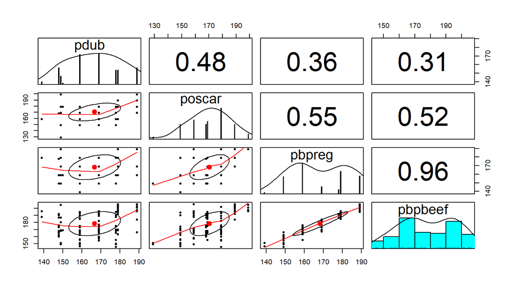

```r
pairs.panels(hotdog[,2:5])
```

## Scatter plot of pdpreg vs. pbpbeef

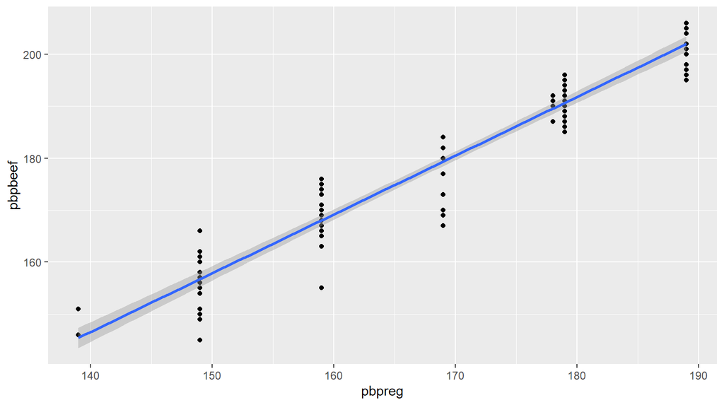

## Drop `pbpreg`

```r
hotdog.lm02 = lm(MKTDUB ~ pdub + poscar + pbpbeef, data=hotdog)
summ(hotdog.lm02, digits = 4, vif=T)
```

```
MODEL INFO:
Observations: 113
Dependent Variable: MKTDUB
Type: OLS linear regression

MODEL FIT:
F(3,109) = 38.6141, p = 0.0000
R² = 0.5152
Adj. R² = 0.5019

Standard errors: OLS
----------------------------------------------------------------
                       Est.     S.E.    t val.        p      VIF
----------------- --------- -------- --------- -------- --------
(Intercept)          0.0450   0.0140    3.2166   0.0017
pdub                -0.0007   0.0001   -9.2656   0.0000   1.3158
poscar               0.0003   0.0001    3.3637   0.0011   1.6216
pbpbeef              0.0004   0.0001    5.6076   0.0000   1.3762
----------------------------------------------------------------
```

## Joint signifance: the F-test

\[\begin{array}{l} {H_0}:{\beta _{pbpreg}} = {\beta _{pbpbeef}} = 0\\ {H_a}:{\beta _{pbpreg}} \ne 0\; \lor \;{\beta _{pbpbeef}} \ne 0 \end{array}\]

This F-test asks: Are they jointly significant?

## The F-Test

```r
car::linearHypothesis(hotdog.lm01, c("pbpreg","pbpbeef"))
```

```
Linear hypothesis test

Hypothesis:
pbpreg = 0
pbpbeef = 0

Model 1: restricted model
Model 2: MKTDUB ~ pdub + poscar + pbpreg + pbpbeef

  Res.Df      RSS Df Sum of Sq      F   Pr(>F)
1    110 0.014258
2    108 0.010816  2 0.0034416 17.182 3.32e-07 ***
---
Signif. codes:  0 '***' 0.001 '**' 0.01 '*' 0.05 '.' 0.1 ' ' 1
```

## You did it!